# ML-Coursera-Project-v1

# Machine Learning Project - John Hopkins / Coursera

### Rafael Sierra

#### May 7th, 2017

## Background

Using devices such as Jawbone Up, Nike FuelBand, and Fitbit it is now possible to collect a large amount of data about personal activity relatively inexpensively. The goal is to use data from accelerometers on the belt, forearm, arm, and dumbell of 6 participants who were asked to perform barbell lifts correctly and incorrectly in 5 different ways.

## Data

The training data for this project are available here: https://d396qusza40orc.cloudfront.net/predmachlearn/pml-training.csv

The test data are available here: https://d396qusza40orc.cloudfront.net/predmachlearn/pml-testing.csv

The data for this project come from this source: http://groupware.les.inf.puc-rio.br/har

## Data Preparation

A seed is set to ensure reproducibility. Also, the proper libraries are called:

```r
library(caret)
```

```r
library(rpart)
library(rpart.plot)
library(randomForest)
set.seed(3245)
```

As a first step, we extract the database presented in the Coursera webpage:

```r
download.file("https://d396qusza40orc.cloudfront.net/predmachlearn/pml-training.csv", destfile = "training.csv", method = "curl")
download.file("https://d396qusza40orc.cloudfront.net/predmachlearn/pml-testing.csv", destfile = "testing.csv", method = "curl")

dataTrain <- read.csv("training.csv", header = TRUE, na.strings=c("NA","#DIV/0!", ""))
dataTest <- read.csv("testing.csv", header = TRUE, na.strings=c("NA","#DIV/0!", ""))
```

Having obtained these databases, we can begin to examine the training dataset (some results are not presented due to their extension):

```r
summary(dataTrain)
str(dataTrain)
```

```r
dim(dataTrain)
```

```
## [1] 19622   160
```

As a result of the preliminar examination we can determine that many variables do not contain relevant data. We can proceed to clean up those variables:

```r
tempTrain <- apply(dataTrain, 2, is.na)
tempTrain <- apply(tempTrain, 2, sum)
tempTrain <- tempTrain > 0
dataTrain <- dataTrain[,!tempTrain]
dataTrain <- dataTrain[,-c(1:7)]

tempTest <- apply(dataTest, 2, is.na)
tempTest <- apply(tempTest, 2, sum)
tempTest <- tempTest > 0
dataTest <- dataTest[,!tempTest]
names(dataTest)[60] <- c("classe")
dataTest <- dataTest[,-c(1:7)]
```

This allows us to eliminate 100 variables, leaving only 60 to work with. Additionally, 7 other variables were removed due to the fact that they didn’t offer valuable information. The final dataset has the following dimensions:

```r
dim(dataTrain)
```

```
## [1] 19622    53
```

In order to be able to apply cross-validation, the training set will be split in two datasets, one for training, with 60%, and one for testing with 40%. The original test set will be used only to run the final predictions once the model has been developed.

```r
partition <- createDataPartition(y=dataTrain$classe, p=0.6, list=FALSE)
trainingSet <- dataTrain[partition,]
testSet <- dataTrain[-partition,]
```

## Model Application

To begin, we can explore the variable “classe” in the training set. This shows we have a 5 levels variable, from A to E. We can explore the distribution of such variable:

```r
summary(trainingSet$classe)
```

```
##    A    B    C    D    E
## 3348 2279 2054 1930 2165
```

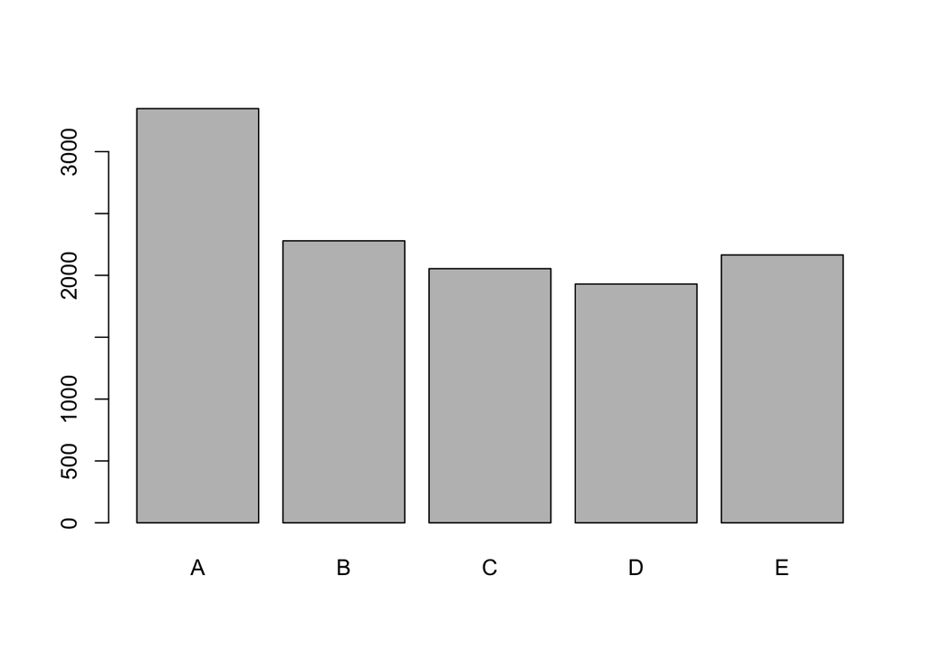

```r
plot(trainingSet$classe)
```

We can see that the frequency has a similar magnitud ranges, however, level A is clearly the most frequent one.

To generate a prediction, we will apply a decision tree model to the training set, given that is clearly a classification problem:

```r
dtmodel <- rpart(classe ~ ., data = trainingSet, method = "class")
dtpredict <- predict(dtmodel, testSet, type = "class")
confusionMatrix(dtpredict, testSet$classe)
```

```
## Confusion Matrix and Statistics
##
##           Reference
## Prediction    A    B    C    D    E
##          A 2073  340   94  227   64
##          B   43  696   54   24   61
##          C   44  275 1108  132  166
##          D   57   97  110  761   93
##          E   15  110    2  142 1058
##
## Overall Statistics
##
##                Accuracy : 0.726
##                  95% CI : (0.716, 0.7358)
##     No Information Rate : 0.2845
##     P-Value [Acc > NIR] : < 2.2e-16
##
##                   Kappa : 0.6505
##  Mcnemar's Test P-Value : < 2.2e-16
##
## Statistics by Class:
##
##                      Class: A Class: B Class: C Class: D Class: E
## Sensitivity            0.9288  0.45850   0.8099  0.59176   0.7337
## Specificity            0.8709  0.97124   0.9048  0.94558   0.9580
## Pos Pred Value         0.7409  0.79271   0.6423  0.68068   0.7973
## Neg Pred Value         0.9685  0.88203   0.9575  0.92197   0.9411
## Prevalence             0.2845  0.19347   0.1744  0.16391   0.1838
## Detection Rate         0.2642  0.08871   0.1412  0.09699   0.1348
## Detection Prevalence   0.3566  0.11190   0.2199  0.14249   0.1691
## Balanced Accuracy      0.8998  0.71487   0.8573  0.76867   0.8458
```

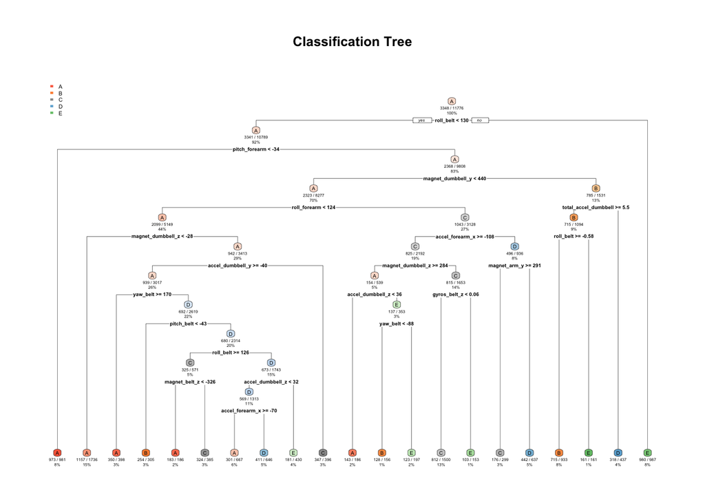

```r
rpart.plot(dtmodel, main="Classification Tree", extra=102, under=TRUE, faclen=0)
```

We can also apply a random forest model in order to compare outputs:

```r
rfmodel <- randomForest(classe ~ ., data = trainingSet, importance = TRUE, ntrees = 10)
rfpredict <- predict(rfmodel, testSet, type = "class")
confusionMatrix(rfpredict, testSet$classe)
```

```
## Confusion Matrix and Statistics
##
##           Reference
## Prediction    A    B    C    D    E
##          A 2231   12    0    0    0
##          B    1 1501    6    0    0
##          C    0    5 1361   14    0
##          D    0    0    1 1272    3
##          E    0    0    0    0 1439
##
## Overall Statistics
##
##                Accuracy : 0.9946
##                  95% CI : (0.9928, 0.9961)
##     No Information Rate : 0.2845
##     P-Value [Acc > NIR] : < 2.2e-16
##
##                   Kappa : 0.9932
##  Mcnemar's Test P-Value : NA
##
## Statistics by Class:
##
##                      Class: A Class: B Class: C Class: D Class: E
## Sensitivity            0.9996   0.9888   0.9949   0.9891   0.9979
## Specificity            0.9979   0.9989   0.9971   0.9994   1.0000
## Pos Pred Value         0.9947   0.9954   0.9862   0.9969   1.0000
## Neg Pred Value         0.9998   0.9973   0.9989   0.9979   0.9995
## Prevalence             0.2845   0.1935   0.1744   0.1639   0.1838
## Detection Rate         0.2843   0.1913   0.1735   0.1621   0.1834
## Detection Prevalence   0.2859   0.1922   0.1759   0.1626   0.1834
## Balanced Accuracy      0.9987   0.9938   0.9960   0.9943   0.9990
```

The model accuracy while using decision tress is 72.6%. The random forest accuracy was calculated in 99.46%, and the out-of-sample error (calculated as [1 - ACCURACY]) is 0.54%.

The result is in accordance with what was expected (that the random forest model would perform better than decision trees). Given this, we will use the random forest model we generated to apply it to the test set. Since we have an accuracy with over 99%, we would expect the result to have very few to none misclassified samples.

## Original Test Set Prediction

We can now proceed to apply the models to the original test data (20 observations) to generate the final result:

```r
dtestrf <- predict(rfmodel, dataTest, type = "class")
dtestrf
```

```
##  1  2  3  4  5  6  7  8  9 10 11 12 13 14 15 16 17 18 19 20
##  B  A  B  A  A  E  D  B  A  A  B  C  B  A  E  E  A  B  B  B
## Levels: A B C D E
```

```r
write.csv(dtestrf, "prediction.csv")
```